# ChemmineR: introductory session

Mik Black

25 October 2016

This material covers a VERY basic introduction to some of the functionality provided by the `ChemmineR` package for R.

It borrows (very) heavily from:

- http://www.bioconductor.org/packages/devel/bioc/vignettes/ChemmineR/inst/doc/ChemmineR.html

### R libraries

The main R package used during this session is `ChemmineR`. You can install this via:

```r
## Source the biocLite.R installation script
source("http://bioconductor.org/biocLite.R")

## Use biocLite to install the package
biocLite("ChemmineR")
```

### Additional complication(s)

Additional functionality can be added to the `ChemmineR` package through the OpenBabel C++ library, accessed via the `ChemmineOB` R package. This provides extra format conversion and local peptide structure viewing capabilities. As described in the manual, `ChemmineR` will automatically detect whether `ChemmineOB` is installed. To get OpenBabel installed on my (Mac OS) laptop, I used the v2.3.1 zip file from:

http://openbabel.org/wiki/Category:Installation

and then installed the `ChemmineOB` package via:

```r
source("http://bioconductor.org/biocLite.R")
biocLite("ChemmineOB")
```

For comparing compounds, and performing clustering, the `fmcsR` package is needed:

```r
source("http://bioconductor.org/biocLite.R")
biocLite("fmcsR")
```

### References

Papers relating to this package and the assocaited “Chemmine” web service:

- Cao, Y., Charisi, A., Cheng, L.-C., Jiang, T., & Girke, T. (2008). ChemmineR: a compound mining framework for R. Bioinformatics (Oxford, England), 24(15), 1733–1734. http://doi.org/10.1093/bioinformatics/btn307
- Backman, T. W. H., Cao, Y., & Girke, T. (2011). ChemMine tools: an online service for analyzing and clustering small molecules. Nucleic Acids Research, 39(suppl), W486–W491. http://doi.org/10.1093/nar/gkr320

Bioconductor page:

- https://www.bioconductor.org/packages/release/bioc/html/ChemmineR.html

### A name you recognise?

- Thomas Girke is an Associate Professor in Bioinformatics at UC Riverside:
  - http://girke.bioinformatics.ucr.edu/
- He has a great page of R manuals:
  - http://girke.bioinformatics.ucr.edu/manuals/mydoc/home.html
- Includes a fantastic one covering various Bioconductor functionality that I have used (and referenced) in my STAT435 lectures:
  - http://manuals.bioinformatics.ucr.edu/home/R_BioCondManual

### The ChemMine website

The ChemMine website provides a collection of tools for working with structure data from small molecules: - drawing structures - similarity searching - clustering

[figure not shown]

Even cooler, all of this functionality can be accessed from within R via the ChemmineR package.

#### http://chemmine.ucr.edu/

### ChemmineR: Getting started

Load the ChemmineR library:

```r
library(ChemmineR)
```

and the `ChemmineOB` package if you have it installed:

```r
library(ChemmineOB)
```

#### Some background: data formats

This data can handle molecular structure data is the following formats:

- SDF
- smiles

Let’s learn what these formats look like by loading some data.

#### Importing SDF objects

Import some SDF data from Thomas’s web page (you can ignore the warning about an “incomplete final line”):

```r
sdfset <- read.SDFset("http://faculty.ucr.edu/~tgirke/Documents/R_BioCond/Samples/sdfsample.sdf")
```

```
## Warning in readLines(sdfstr): incomplete final line found on 'http://
## faculty.ucr.edu/~tgirke/Documents/R_BioCond/Samples/sdfsample.sdf'
```

```
## Warning in matrix(as.numeric(ctma[, -4]), nrow = length(ct), ncol = Ncol
## - : NAs introduced by coercion
```

```
## Warning in read.SDFset("http://faculty.ucr.edu/~tgirke/Documents/R_BioCond/
## Samples/sdfsample.sdf"): 1 invalid SDFs detected. To fix, run: valid <-
## validSDF(sdfset); sdfset <- sdfset[valid]
```

What sort of data is it?

```r
## Class?
class(sdfset)
```

```
## [1] "SDFset"
## attr(,"package")
## [1] "ChemmineR"
```

```r
## Length?
length(sdfset)
```

```
## [1] 86
```

```r
## First component?
sdfset[[1]]
```

```
## An instance of "SDF"
##
## <<header>>
##                             Molecule_Name
##                                  "650001"
##                                    Source
##                  "  -OEChem-07071010512D"
##                                   Comment
##                                        ""
##                               Counts_Line
## " 61 64  0     0  0  0  0  0  0999 V2000"
##
## <<atomblock>>
##           C1      C2  C3  C5  C6  C7  C8  C9 C10 C11 C12 C13 C14 C15 C16
## O_1   7.0468  0.0839   0   0   0   0   0   0   0   0   0   0   0   0   0
## O_2  12.2708  1.0492   0   0   0   0   0   0   0   0   0   0   0   0   0
## ...      ...     ... ... ... ... ... ... ... ... ... ... ... ... ... ...
## H_60  1.8411 -1.5985   0   0   0   0   0   0   0   0   0   0   0   0   0
## H_61  2.6597 -1.2843   0   0   0   0   0   0   0   0   0   0   0   0   0
##
## <<bondblock>>
##      C1  C2  C3  C4  C5  C6  C7
## 1     1  16   2   0   0   0   0
## 2     2  23   1   0   0   0   0
## ... ... ... ... ... ... ... ...
## 63   33  60   1   0   0   0   0
## 64   33  61   1   0   0   0   0
##
## <<datablock>> (33 data items)
##           PUBCHEM_COMPOUND_CID PUBCHEM_COMPOUND_CANONICALIZED
##                       "650001"                            "1"
##      PUBCHEM_CACTVS_COMPLEXITY  PUBCHEM_CACTVS_HBOND_ACCEPTOR
##                          "700"                            "7"
##
##                          "..."
```

NB: need to be a little bit careful with accessing the objects (note the different effect of vector-style *versus* list-style):

```r
class(sdfset[1])
```

```
## [1] "SDFset"
## attr(,"package")
## [1] "ChemmineR"
```

```r
sdfset[1]
```

```
## An instance of "SDFset" with 1 molecules
```

```r
class(sdfset[[1]])
```

```
## [1] "SDF"
## attr(,"package")
## [1] "ChemmineR"
```

```r
sdfset[[1]]
```

```
## An instance of "SDF"
##
## <<header>>
##                             Molecule_Name
##                                  "650001"
##                                    Source
##                  "  -OEChem-07071010512D"
##                                   Comment
##                                        ""
##                               Counts_Line
## " 61 64  0     0  0  0  0  0  0999 V2000"
##
## <<atomblock>>
##           C1      C2  C3  C5  C6  C7  C8  C9 C10 C11 C12 C13 C14 C15 C16
## O_1   7.0468  0.0839   0   0   0   0   0   0   0   0   0   0   0   0   0
## O_2  12.2708  1.0492   0   0   0   0   0   0   0   0   0   0   0   0   0
## ...      ...     ... ... ... ... ... ... ... ... ... ... ... ... ... ...
## H_60  1.8411 -1.5985   0   0   0   0   0   0   0   0   0   0   0   0   0
## H_61  2.6597 -1.2843   0   0   0   0   0   0   0   0   0   0   0   0   0
##
## <<bondblock>>
##      C1  C2  C3  C4  C5  C6  C7
## 1     1  16   2   0   0   0   0
## 2     2  23   1   0   0   0   0
## ... ... ... ... ... ... ... ...
## 63   33  60   1   0   0   0   0
## 64   33  61   1   0   0   0   0
##
## <<datablock>> (33 data items)
##           PUBCHEM_COMPOUND_CID PUBCHEM_COMPOUND_CANONICALIZED
##                       "650001"                            "1"
##      PUBCHEM_CACTVS_COMPLEXITY  PUBCHEM_CACTVS_HBOND_ACCEPTOR
##                          "700"                            "7"
##
##                          "..."
```

This means that `sdf.visualize( sdfset[1] )` will succeed (as it requires a SDFset object), but `sdf.visualize( sdfset[[1]] )` will fail, since `sdfset[[1]]` is a “SDF”, not a “SDFset”.

What can we do with this information? Let’s try plotting it. This command:

```r
## Opens browser window and plots structure using Chemmine web service
sdf.visualize( sdfset[1] )
```

If you have the OpenBabel package installed, the following command will plot the structure in R:

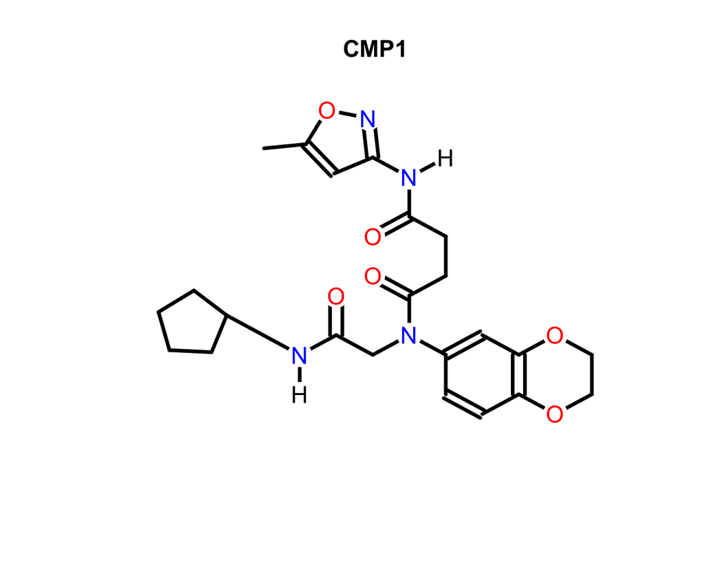

```r
## With the ChemmineOB package loaded (and OpenBabel installed) you can plot locally:
plot(sdfset[1], regenCoords=TRUE, print=FALSE)
```

You can also plot multiple compounds from a SDFset:

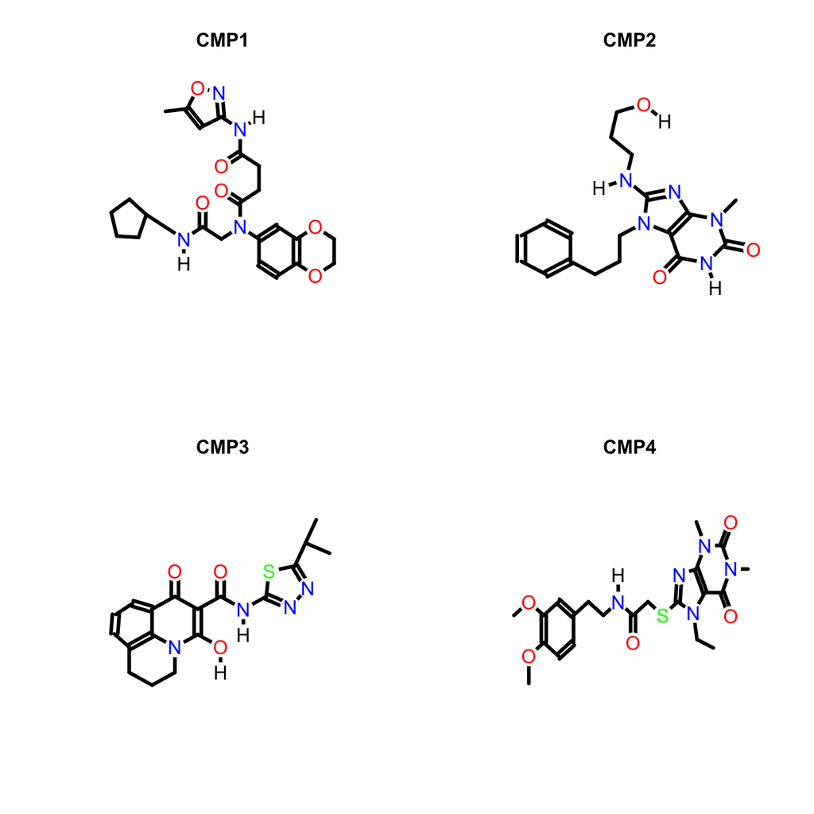

```r
## With the ChemmineOB package loaded (and OpenBabel installed) you can plot locally:
plot(sdfset[1:4], regenCoords=TRUE, print=FALSE)
```

What about the other (smiles) format? With OpenBabel, we can do format conversion:

```r
smileset <- sdf2smiles(sdfset)
```

What does this format look like?

```r
##
## Display the first smiles object
smileset[[1]]
```

```
## An instance of "SMI"
## [1] "O=C(NC1CCCC1)CN(c1cc2OCCOc2cc1)C(=O)CCC(=O)Nc1noc(c1)C"
```

There are also functions for importing (and exporting) smiles data.

## What else can we do?

Who wouldn’t want to identify rings?!

```r
ringatoms <- rings(sdfset[1], upper=Inf, type="all", arom=FALSE, inner=FALSE)
## What did we get?
ringatoms
```

```
## $ring1
## [1] "N_10" "O_6"  "C_32" "C_31" "C_30"
##
## $ring2
## [1] "C_12" "C_14" "C_15" "C_13" "C_11"
##
## $ring3
## [1] "C_23" "O_2"  "C_27" "C_28" "O_3"  "C_25"
##
## $ring4
## [1] "C_23" "C_21" "C_18" "C_22" "C_26" "C_25"
##
## $ring5
##  [1] "O_3"  "C_28" "C_27" "O_2"  "C_23" "C_21" "C_18" "C_22" "C_26" "C_25"
```

And plot them! (rings are highlighted in red).

```r
atomindex <- as.numeric(gsub(".*_", "", unique(unlist(ringatoms))))
atomindex
```

```
##  [1] 10  6 32 31 30 12 14 15 13 11 23  2 27 28  3 25 21 18 22 26
```

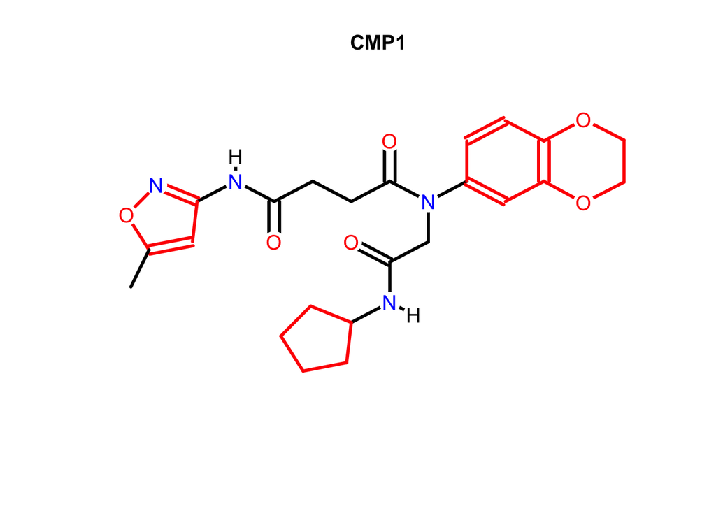

```r
plot(sdfset[1], griddim=c(1,1), print=FALSE, colbonds=atomindex)
```

NB: using the `griddim` parameter above allows you to specify the layout of the plot (like the `mfrow` amd `mfcol` parameters in teh base `plot` command). If you don’t specify it, teh SDF plotting function will figure it out for you (which is cool), but it also seems to remember it for next time (which isn’t cool if you are plotting a different number of molecules).

You can even plot the atoms if you want…

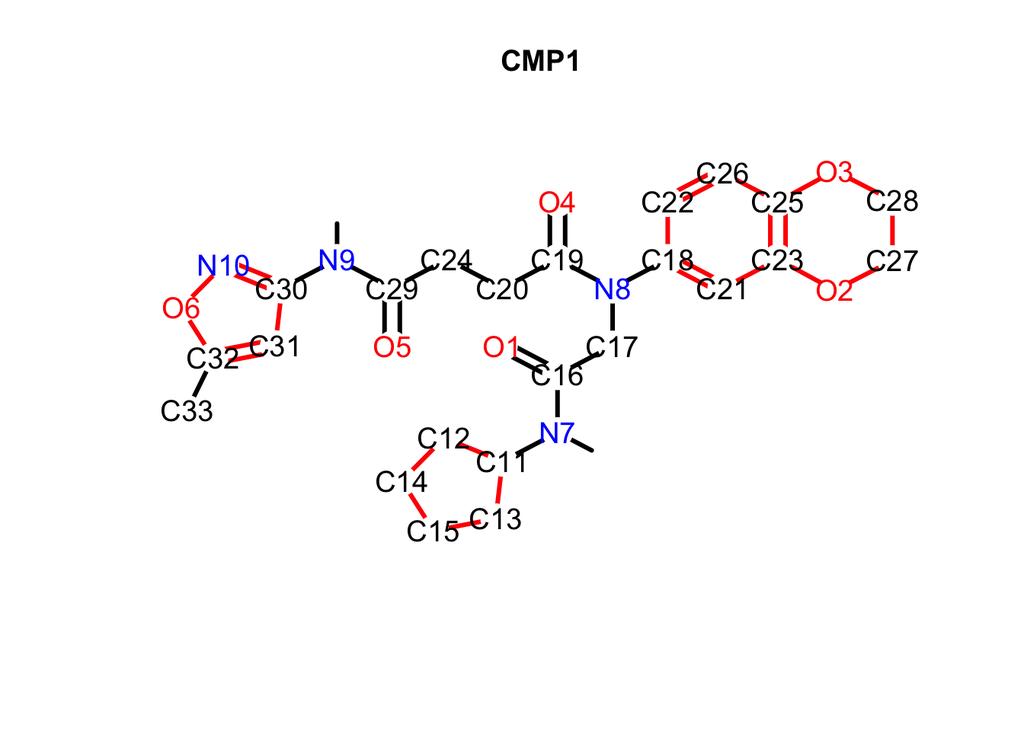

```r
plot(sdfset[1], print=FALSE, atomnum=TRUE, no_print_atoms="H", colbonds=atomindex)
```